# Análisis de Enriquecimiento Funcional de Genes

Hugo Salas Calderón

2025-11-02

# 1 Introducción

Este informe presenta el análisis de enriquecimiento funcional de genes realizado mediante el script `functional_analysis.py`. El análisis utiliza **g:Profiler** para consultar las bases de datos:

- **GO:BP** (Gene Ontology - Biological Process)
- **KEGG** (Kyoto Encyclopedia of Genes and Genomes)
- **REAC** (Reactome Pathway Database)

El objetivo es identificar procesos biológicos, vías metabólicas y vías de reacción significativamente enriquecidas en el conjunto de genes analizado.

## 1.1 Metodología

### 1.1.1 Pipeline de análisis

El análisis se realizó en dos fases:

**Fase 1: Análisis funcional (Python)**

- Validación de genes con MyGene.info
- Búsqueda automática de variantes mitocondriales (ND1 → MT-ND1)
- Análisis de enriquecimiento con g:Profiler (FDR < 0.05)
- Exportación de resultados por base de datos

**Fase 2: Análisis estadístico y visualización (R)**

Este documento procesa y visualiza los resultados para:

- Análisis exploratorio de datos
- Generación de visualizaciones
- Análisis comparativo entre bases de datos
- Identificación de patrones funcionales

# 2 Entorno de ejecución

## 2.1 Información del sistema

La ejecución se ha hecho en el siguiente ordenador:

| OS | **unix** | OS version | **Ubuntu 25.04** |
| --- | --- | --- | --- |
| sysname | **Linux** | nodename | **husaka-ROG-Zephyrus-G14-GA401QM** |
| machine | **x86_64** | user | **husaka** |
| Graphical interface | **X11** | R version | **R version 4.4.3 (2025-02-28)**. |

## 2.2 Estructura de directorios

```
proyecto/
├── data/
│   └── genes_input.txt
├── scripts/
│   └── enrichment_analysis.Rmd    ← Este archivo
│   └── functional_analysis.py
├── results/
│   ├── validacion_genes.csv
│   ├── resultados_completos.csv
│   ├── GO_BP_resultados.csv
│   ├── KEGG_resultados.csv
│   ├── REAC_resultados.csv
│   └── R/                         ← Outputs de este análisis
│       ├── *.png
│       └── *.csv
├── requirements.txt
├── README.md
```

# 3 Carga de datos

```r
# Verificar que los archivos existen
archivos_requeridos <- c(
  "validacion_genes.csv",
  "resultados_completos.csv",
  "GO_BP_resultados.csv",
  "KEGG_resultados.csv",
  "REAC_resultados.csv"
)

archivos_faltantes <- c()
for (archivo in archivos_requeridos) {
  if (!file.exists(file.path("../results", archivo))) {
    archivos_faltantes <- c(archivos_faltantes, archivo)
  }
}

if (length(archivos_faltantes) > 0) {
  stop(paste("Error: Archivos faltantes en ../results/:\n",
             paste(archivos_faltantes, collapse = "\n")))
}

# Leer validación de genes
validacion <- leer_resultados("validacion_genes.csv")

# Leer resultados completos
resultados <- leer_resultados("resultados_completos.csv")

# Leer por base de datos
go_bp <- leer_resultados("GO_BP_resultados.csv")
kegg <- leer_resultados("KEGG_resultados.csv")
reactome <- leer_resultados("REAC_resultados.csv")
```

## 3.1 Resumen de datos cargados

**Datos cargados exitosamente**

- **Genes validados:** 3 genes
- **Términos enriquecidos:** 86 términos
  - GO:BP: 65 términos
  - KEGG: 12 términos
  - Reactome: 9 términos

# 4 Validación de genes

## 4.1 Tabla de validación

```r
# Crear tabla con colores condicionales
tabla_val <- validacion %>%
  mutate(
    gen_input = cell_spec(gen_input, bold = TRUE, color = "black"),
    gen_validado = cell_spec(
      gen_validado,
      bold = TRUE,
      color = ifelse(estado == "valido", "#27ae60", "#e74c3c")
    ),
    estado = cell_spec(
      estado,
      bold = TRUE,
      background = ifelse(estado == "valido", "#d5f4e6", "#fadbd8")
    )
  )

# Renderizar tabla
tabla_val %>%
  kbl(
    caption = "Validación y conversión de identificadores de genes",
    escape = FALSE,
    align = "c"
  ) %>%
  kable_styling(
    bootstrap_options = c("striped", "hover", "condensed", "responsive"),
    full_width = FALSE,
    position = "center",
    font_size = 13
  ) %>%
  row_spec(0, bold = TRUE, color = "white", background = "#3498db")
```

Validación y conversión de identificadores de genes

| gen_input | gen_validado | estado | notas |
| --- | --- | --- | --- |
| COX4I2 | COX4I2 | valido | Validado |
| ND1 | MT-ND1 | valido | Convertido de ND1 |
| ATP6 | MT-ATP6 | valido | Convertido de ATP6 |

## 4.2 Resumen de validación

```r
# Estadísticas de validación
n_validos <- sum(validacion$estado == "valido", na.rm = TRUE)
n_no_encontrados <- sum(validacion$estado == "no_encontrado", na.rm = TRUE)
n_convertidos <- sum(validacion$gen_input != validacion$gen_validado &
                     validacion$estado == "valido", na.rm = TRUE)
```

**Resumen de validación:**

- **Genes válidos:** 3 de 3 genes
- **Genes convertidos:** 2 (ej. ND1 → MT-ND1)
- **Genes no encontrados:** 0

# 5 Análisis exploratorio

## 5.1 Distribución de p-valores

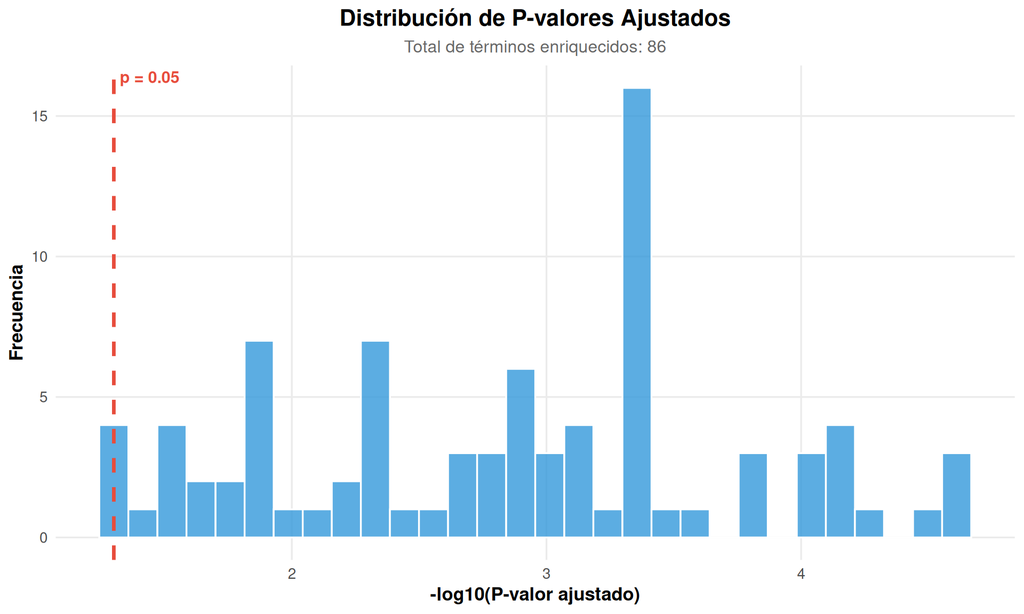

**Figura 1**: Distribución de p-valores ajustados de los términos enriquecidos

```r
# Crear histograma
p1 <- ggplot(resultados, aes(x = -log10(p_value))) +
  geom_histogram(bins = 30, fill = "#3498db", color = "white", alpha = 0.8) +
  geom_vline(xintercept = -log10(0.05), linetype = "dashed",
             color = "#e74c3c", size = 1.2) +
  annotate("text", x = -log10(0.05), y = Inf,
           label = "p = 0.05", vjust = 1.5, hjust = -0.1,
           color = "#e74c3c", fontface = "bold", size = 4) +
  theme_minimal(base_size = 13) +
  labs(
    title = "Distribución de P-valores Ajustados",
    subtitle = sprintf("Total de términos enriquecidos: %d", nrow(resultados)),
    x = "-log10(P-valor ajustado)",
    y = "Frecuencia"
  ) +
  theme(
    plot.title = element_text(face = "bold", hjust = 0.5, size = 16),
    plot.subtitle = element_text(hjust = 0.5, size = 12, color = "gray40"),
    axis.title = element_text(face = "bold", size = 13),
    panel.grid.minor = element_blank()
  )

print(p1)

# Guardar gráfico
guardar_grafico(p1, "distribucion_pvalores.png", width = 10, height = 6)
```

## 5.2 Estadísticas por base de datos

```r
# Calcular estadísticas por base de datos
stats_bd <- resultados %>%
  group_by(source) %>%
  summarise(
    n_terminos = n(),
    p_mediana = median(p_value),
    p_minimo = min(p_value),
    genes_promedio = round(mean(intersection_size), 1),
    genes_max = max(intersection_size),
    .groups = 'drop'
  ) %>%
  arrange(desc(n_terminos))

# Crear tabla
stats_bd %>%
  mutate(
    source = cell_spec(source, bold = TRUE, color = "white",
                      background = case_when(
                        source == "GO:BP" ~ "#e74c3c",
                        source == "KEGG" ~ "#3498db",
                        source == "REAC" ~ "#2ecc71",
                        TRUE ~ "#95a5a6"
                      )),
    p_mediana = sprintf("%.2e", p_mediana),
    p_minimo = sprintf("%.2e", p_minimo)
  ) %>%
  kbl(
    caption = "Estadísticas descriptivas por base de datos",
    escape = FALSE,
    align = c("l", "c", "c", "c", "c", "c"),
    col.names = c("Base de Datos", "N° Términos", "P-valor Mediana",
                  "P-valor Mínimo", "Genes Promedio", "Genes Máximo")
  ) %>%
  kable_styling(
    bootstrap_options = c("striped", "hover", "condensed"),
    full_width = FALSE,
    position = "center",
    font_size = 12
  ) %>%
  row_spec(0, bold = TRUE, color = "white", background = "#34495e")
```

Estadísticas descriptivas por base de datos

| Base de Datos | N° Términos | P-valor Mediana | P-valor Mínimo | Genes Promedio | Genes Máximo |
| --- | --- | --- | --- | --- | --- |
| GO:BP | 65 | 1.14e-03 | 2.45e-05 | 2.1 | 3 |
| KEGG | 12 | 8.96e-05 | 5.78e-05 | 2.8 | 3 |
| REAC | 9 | 2.27e-02 | 8.64e-04 | 1.4 | 2 |

```r
# Exportar tabla
exportar_csv(stats_bd, "resumen_estadisticas_bd.csv")
```

# 6 Top términos enriquecidos

## 6.1 Top 20 términos globales

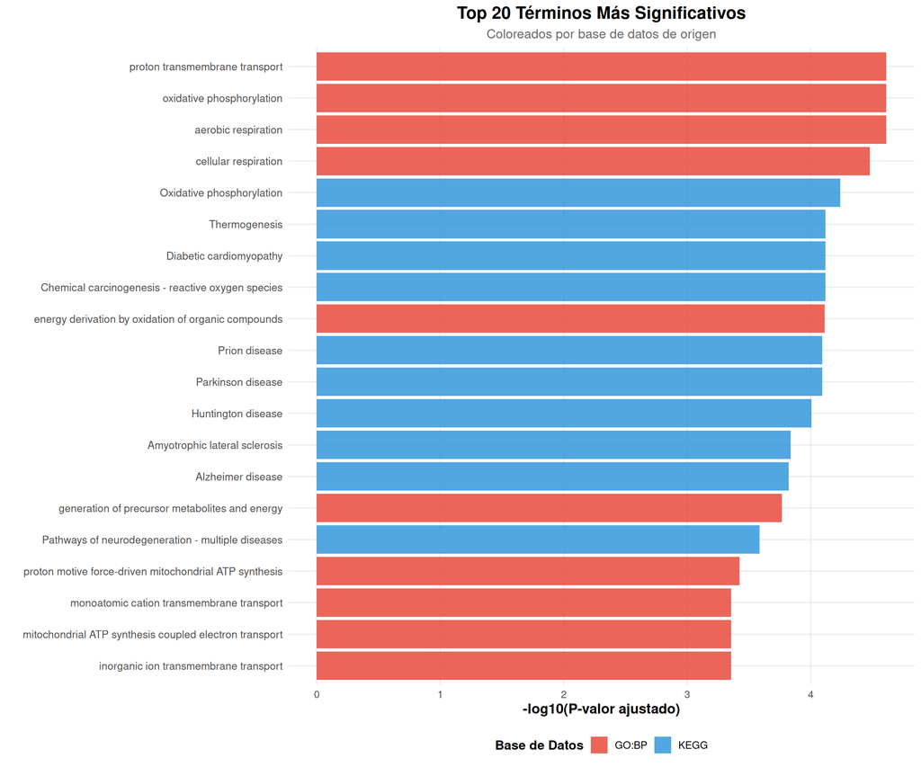

**Figura 2**: Top 20 términos más significativos (todas las bases de datos)

```r
# Seleccionar top 20
top20 <- resultados %>%
  arrange(p_value) %>%
  head(20) %>%
  mutate(
    name_short = ifelse(nchar(name) > 55,
                        paste0(substr(name, 1, 52), "..."),
                        name),
    neg_log_p = -log10(p_value)
  )

# Colores por base de datos
colores_bd <- c("GO:BP" = "#e74c3c", "KEGG" = "#3498db", "REAC" = "#2ecc71")

# Crear gráfico
p2 <- ggplot(top20, aes(x = neg_log_p,
                         y = reorder(name_short, neg_log_p),
                         fill = source)) +
  geom_bar(stat = "identity", alpha = 0.85) +
  scale_fill_manual(values = colores_bd, name = "Base de Datos") +
  theme_minimal(base_size = 12) +
  labs(
    title = "Top 20 Términos Más Significativos",
    subtitle = "Coloreados por base de datos de origen",
    x = "-log10(P-valor ajustado)",
    y = ""
  ) +
  theme(
    plot.title = element_text(face = "bold", hjust = 0.5, size = 16),
    plot.subtitle = element_text(hjust = 0.5, size = 12, color = "gray40"),
    axis.text.y = element_text(size = 10),
    axis.title = element_text(face = "bold", size = 13),
    legend.position = "bottom",
    legend.title = element_text(face = "bold"),
    panel.grid.minor = element_blank()
  )

print(p2)

# Guardar gráfico
guardar_grafico(p2, "top20_terminos.png", width = 12, height = 10)
```

## 6.2 Tabla de top 10 términos

```r
# Top 10 para tabla detallada
top10_tabla <- resultados %>%
  arrange(p_value) %>%
  head(10) %>%
  select(source, name, p_value, intersection_size, term_size)

# Crear tabla
top10_tabla %>%
  mutate(
    source = cell_spec(source, bold = TRUE, color = "white",
                      background = case_when(
                        source == "GO:BP" ~ "#e74c3c",
                        source == "KEGG" ~ "#3498db",
                        source == "REAC" ~ "#2ecc71"
                      )),
    name = substr(name, 1, 60),
    p_value = cell_spec(sprintf("%.2e", p_value),
                       color = ifelse(p_value < 0.001, "#e74c3c", "black"),
                       bold = ifelse(p_value < 0.001, TRUE, FALSE)),
    ratio = sprintf("%d/%d", intersection_size, term_size)
  ) %>%
  select(-term_size) %>%
  kbl(
    caption = "Top 10 términos más significativos - Detalles",
    escape = FALSE,
    align = c("c", "l", "c", "c", "c"),
    col.names = c("Base de Datos", "Nombre del Término", "P-valor",
                  "N° Genes", "Ratio")
  ) %>%
  kable_styling(
    bootstrap_options = c("striped", "hover", "condensed"),
    full_width = TRUE,
    font_size = 11
  ) %>%
  row_spec(0, bold = TRUE, color = "white", background = "#34495e") %>%
  column_spec(2, width = "25em")
```

Top 10 términos más significativos - Detalles

| Base de Datos | Nombre del Término | P-valor | N° Genes | Ratio |
| --- | --- | --- | --- | --- |
| GO:BP | proton transmembrane transport | 2.45e-05 | 3 | 3/190 |
| GO:BP | oxidative phosphorylation | 2.45e-05 | 3 | 3/146 |
| GO:BP | aerobic respiration | 2.45e-05 | 3 | 3/199 |
| GO:BP | cellular respiration | 3.31e-05 | 3 | 3/242 |
| KEGG | Oxidative phosphorylation | 5.78e-05 | 3 | 3/134 |
| KEGG | Diabetic cardiomyopathy | 7.57e-05 | 3 | 3/202 |
| KEGG | Chemical carcinogenesis - reactive oxygen species | 7.57e-05 | 3 | 3/221 |
| KEGG | Thermogenesis | 7.57e-05 | 3 | 3/232 |
| GO:BP | energy derivation by oxidation of organic compounds | 7.71e-05 | 3 | 3/345 |
| KEGG | Prion disease | 8.06e-05 | 3 | 3/271 |

# 7 Análisis por base de datos

## 7.1 Gene Ontology

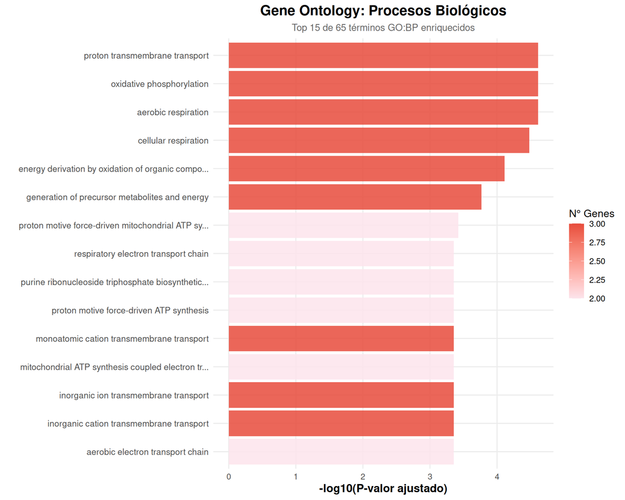

**Figura 3**: Top 15 procesos biológicos (Gene Ontology)

```r
if (nrow(go_bp) > 0) {

  # Top 15 GO:BP
  top_go <- go_bp %>%
    arrange(p_value) %>%
    head(15) %>%
    mutate(
      name_short = ifelse(nchar(name) > 50,
                          paste0(substr(name, 1, 47), "..."),
                          name),
      neg_log_p = -log10(p_value)
    )

  # Gráfico GO:BP
  p3 <- ggplot(top_go, aes(x = neg_log_p,
                            y = reorder(name_short, neg_log_p),
                            fill = intersection_size)) +
    geom_bar(stat = "identity", alpha = 0.85) +
    scale_fill_gradient(low = "#fce4ec", high = "#e74c3c",
                        name = "N° Genes") +
    theme_minimal(base_size = 12) +
    labs(
      title = "Gene Ontology: Procesos Biológicos",
      subtitle = sprintf("Top 15 de %d términos GO:BP enriquecidos", nrow(go_bp)),
      x = "-log10(P-valor ajustado)",
      y = ""
    ) +
    theme(
      plot.title = element_text(face = "bold", hjust = 0.5, size = 16),
      plot.subtitle = element_text(hjust = 0.5, size = 11, color = "gray40"),
      axis.text.y = element_text(size = 10),
      axis.title = element_text(face = "bold", size = 13),
      legend.position = "right",
      panel.grid.minor = element_blank()
    )

  print(p3)

  # Guardar gráfico
  guardar_grafico(p3, "go_bp_top15.png", width = 10, height = 8)

} else {
  cat("No se encontraron términos GO:BP enriquecidos.\n")
}
```

## 7.2 KEGG Pathways

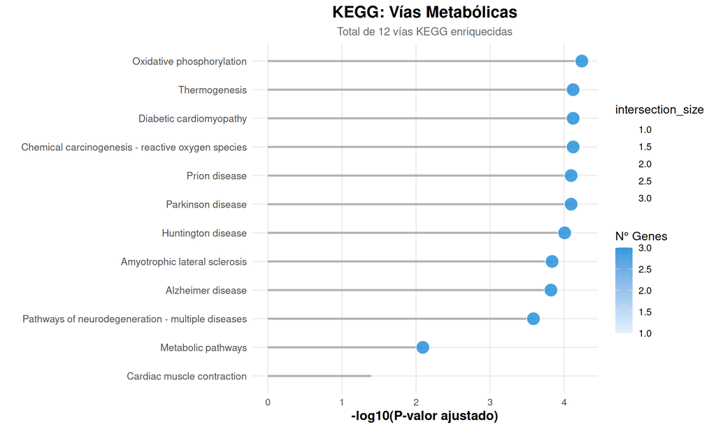

**Figura 4**: Vías metabólicas KEGG

```r
if (nrow(kegg) > 0) {

  # Procesar KEGG
  top_kegg <- kegg %>%
    arrange(p_value) %>%
    head(min(15, nrow(kegg))) %>%
    mutate(
      name_short = ifelse(nchar(name) > 50,
                          paste0(substr(name, 1, 47), "..."),
                          name),
      neg_log_p = -log10(p_value)
    )

  # Gráfico KEGG - Dot plot
  p4 <- ggplot(top_kegg, aes(x = neg_log_p,
                              y = reorder(name_short, neg_log_p))) +
    geom_segment(aes(x = 0, xend = neg_log_p,
                     y = name_short, yend = name_short),
                 color = "gray70", size = 1) +
    geom_point(aes(size = intersection_size, fill = intersection_size),
               shape = 21, color = "white", alpha = 0.9) +
    scale_fill_gradient(low = "#e3f2fd", high = "#3498db",
                        name = "N° Genes") +
    theme_minimal(base_size = 12) +
    labs(
      title = "KEGG: Vías Metabólicas",
      subtitle = sprintf("Total de %d vías KEGG enriquecidas", nrow(kegg)),
      x = "-log10(P-valor ajustado)",
      y = ""
    ) +
    theme(
      plot.title = element_text(face = "bold", hjust = 0.5, size = 16),
      plot.subtitle = element_text(hjust = 0.5, size = 11, color = "gray40"),
      axis.text.y = element_text(size = 10),
      axis.title = element_text(face = "bold", size = 13),
      legend.position = "right",
      panel.grid.minor = element_blank()
    )

  print(p4)

  # Guardar gráfico
  guardar_grafico(p4, "kegg_pathways.png", width = 10, height = 6)

} else {
  cat("No se encontraron vías KEGG enriquecidas.\n")
}
```

## 7.3 Reactome Pathways

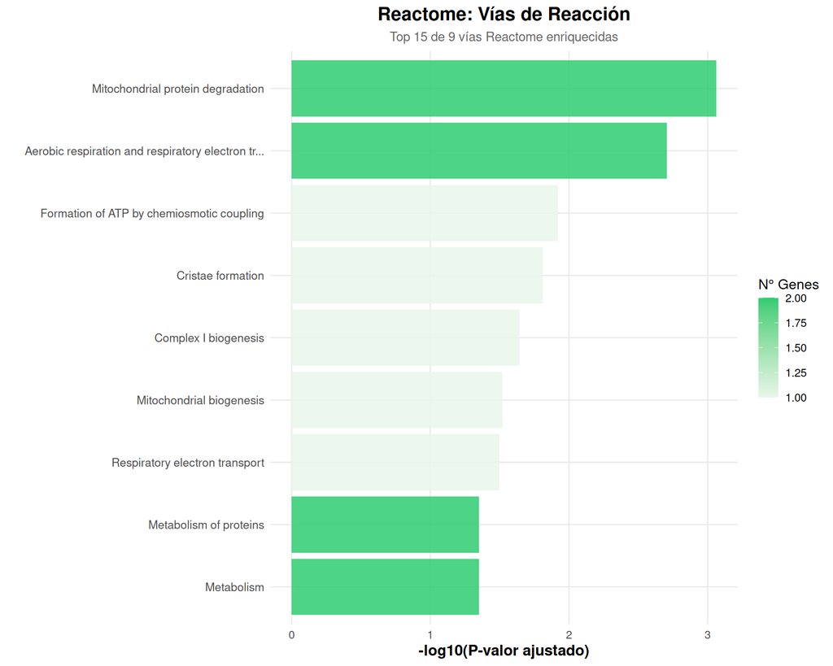

**Figura 5**: Vías de reacción Reactome

```r
if (nrow(reactome) > 0) {

  # Top Reactome
  top_reac <- reactome %>%
    arrange(p_value) %>%
    head(15) %>%
    mutate(
      name_short = ifelse(nchar(name) > 50,
                          paste0(substr(name, 1, 47), "..."),
                          name),
      neg_log_p = -log10(p_value)
    )

  # Gráfico Reactome
  p5 <- ggplot(top_reac, aes(x = neg_log_p,
                              y = reorder(name_short, neg_log_p),
                              fill = intersection_size)) +
    geom_bar(stat = "identity", alpha = 0.85) +
    scale_fill_gradient(low = "#e8f5e9", high = "#2ecc71",
                        name = "N° Genes") +
    theme_minimal(base_size = 12) +
    labs(
      title = "Reactome: Vías de Reacción",
      subtitle = sprintf("Top 15 de %d vías Reactome enriquecidas", nrow(reactome)),
      x = "-log10(P-valor ajustado)",
      y = ""
    ) +
    theme(
      plot.title = element_text(face = "bold", hjust = 0.5, size = 16),
      plot.subtitle = element_text(hjust = 0.5, size = 11, color = "gray40"),
      axis.text.y = element_text(size = 10),
      axis.title = element_text(face = "bold", size = 13),
      legend.position = "right",
      panel.grid.minor = element_blank()
    )

  print(p5)

  # Guardar gráfico
  guardar_grafico(p5, "reactome_pathways.png", width = 10, height = 8)

} else {
  cat("No se encontraron vías Reactome enriquecidas.\n")
}
```

# 8 Comparación entre bases de datos

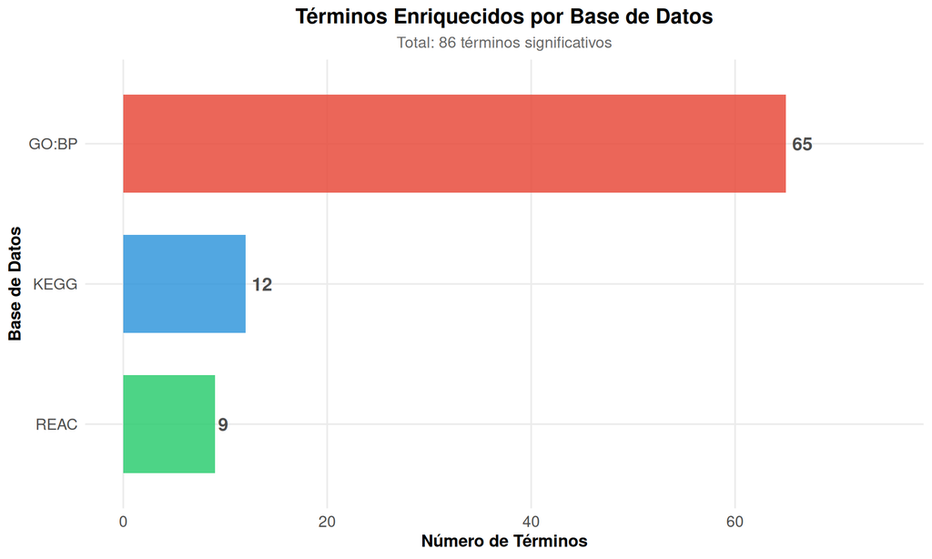

**Figura 6**: Comparación del número de términos enriquecidos por base de datos

```r
# Resumen por base de datos
comparacion <- resultados %>%
  group_by(source) %>%
  summarise(
    n_terminos = n(),
    p_mediana = median(p_value),
    .groups = 'drop'
  ) %>%
  arrange(desc(n_terminos))

# Gráfico comparativo
p6 <- ggplot(comparacion, aes(x = reorder(source, n_terminos),
                               y = n_terminos,
                               fill = source)) +
  geom_bar(stat = "identity", show.legend = FALSE, alpha = 0.85, width = 0.7) +
  geom_text(aes(label = n_terminos), hjust = -0.3,
            size = 5, fontface = "bold", color = "gray30") +
  coord_flip() +
  scale_fill_manual(values = colores_bd) +
  theme_minimal(base_size = 13) +
  labs(
    title = "Términos Enriquecidos por Base de Datos",
    subtitle = sprintf("Total: %d términos significativos", nrow(resultados)),
    x = "Base de Datos",
    y = "Número de Términos"
  ) +
  theme(
    plot.title = element_text(face = "bold", hjust = 0.5, size = 16),
    plot.subtitle = element_text(hjust = 0.5, size = 12, color = "gray40"),
    axis.text = element_text(size = 12),
    axis.title = element_text(face = "bold", size = 13),
    panel.grid.minor = element_blank()
  ) +
  ylim(0, max(comparacion$n_terminos) * 1.15)

print(p6)

# Guardar gráfico
guardar_grafico(p6, "comparacion_bases_datos.png", width = 10, height = 6)
```

# 9 Análisis de convergencia funcional

```r
# Buscar términos relacionados con función mitocondrial
palabras_clave <- c("mitochondrial", "respiratory", "oxidative", "ATP",
                    "electron", "energy", "phosphorylation", "NADH",
                    "complex", "cytochrome")

# Filtrar términos mitocondriales
terminos_mitocondriales <- resultados %>%
  filter(stringr::str_detect(tolower(name),
                            paste(palabras_clave, collapse = "|"))) %>%
  arrange(p_value)

# Resumen por base de datos
resumen_mito <- terminos_mitocondriales %>%
  group_by(source) %>%
  summarise(n_terminos = n(), .groups = 'drop')

# Tabla de resumen
if (nrow(resumen_mito) > 0) {
  resumen_mito %>%
    mutate(
      source = cell_spec(source, bold = TRUE, color = "white",
                        background = case_when(
                          source == "GO:BP" ~ "#e74c3c",
                          source == "KEGG" ~ "#3498db",
                          source == "REAC" ~ "#2ecc71"
                        )),
      porcentaje = sprintf("%.1f%%", n_terminos / nrow(resultados) * 100)
    ) %>%
    kbl(
      caption = "Términos relacionados con función mitocondrial/respiratoria",
      escape = FALSE,
      align = "c",
      col.names = c("Base de Datos", "N° Términos", "% del Total")
    ) %>%
    kable_styling(
      bootstrap_options = c("striped", "hover", "condensed"),
      full_width = FALSE,
      position = "center"
    ) %>%
    row_spec(0, bold = TRUE, color = "white", background = "#34495e")

  # Exportar términos mitocondriales
  exportar_csv(terminos_mitocondriales, "terminos_mitocondriales.csv")
}
```

**Análisis de convergencia:**

Se identificaron **20** términos relacionados con función mitocondrial y respiratoria, lo que representa el **23.3%** del total de términos enriquecidos.

Esto indica cierta coherencia funcional en el conjunto de genes analizado.

# 10 Dot plot integrado

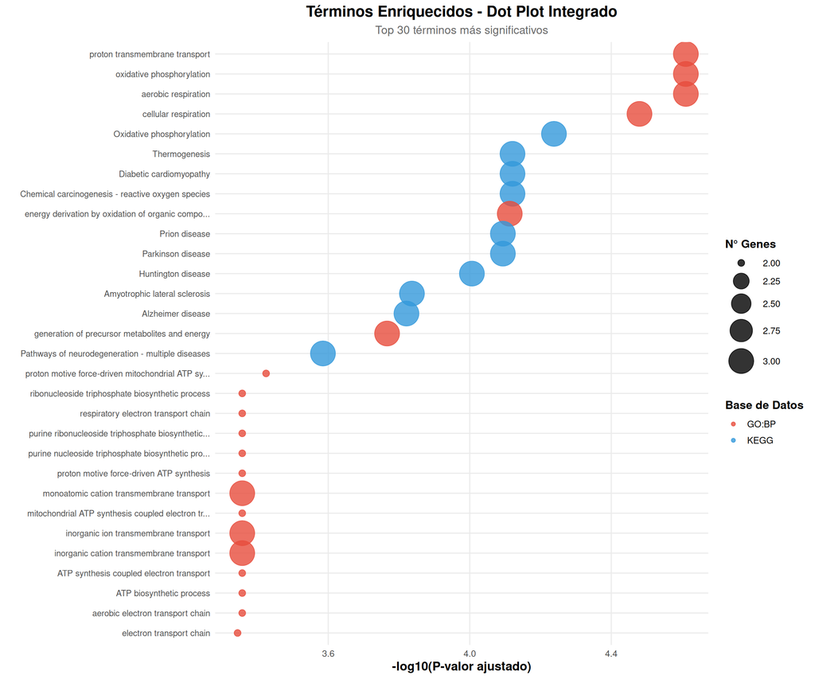

**Figura 7**: Dot plot de los 30 términos más significativos

```r
# Top 30 para dot plot
top30 <- resultados %>%
  arrange(p_value) %>%
  head(30) %>%
  mutate(
    name_short = ifelse(nchar(name) > 50,
                        paste0(substr(name, 1, 47), "..."),
                        name),
    neg_log_p = -log10(p_value)
  )

# Crear dot plot
p7 <- ggplot(top30, aes(x = neg_log_p,
                         y = reorder(name_short, neg_log_p),
                         size = intersection_size,
                         color = source)) +
  geom_point(alpha = 0.8) +
  scale_color_manual(values = colores_bd, name = "Base de Datos") +
  scale_size_continuous(range = c(3, 12), name = "N° Genes") +
  theme_minimal(base_size = 12) +
  labs(
    title = "Términos Enriquecidos - Dot Plot Integrado",
    subtitle = "Top 30 términos más significativos",
    x = "-log10(P-valor ajustado)",
    y = ""
  ) +
  theme(
    plot.title = element_text(face = "bold", hjust = 0.5, size = 16),
    plot.subtitle = element_text(hjust = 0.5, size = 12, color = "gray40"),
    axis.text.y = element_text(size = 9),
    axis.title = element_text(face = "bold", size = 13),
    legend.position = "right",
    legend.title = element_text(face = "bold"),
    panel.grid.minor = element_blank()
  )

print(p7)

# Guardar gráfico
guardar_grafico(p7, "dotplot_integrado.png", width = 12, height = 10)
```

# 11 Conclusiones

## 11.1 Hallazgos principales

1. **Validación de genes:** 3 de 3 genes fueron validados correctamente, incluyendo 2 conversión(es) automática(s) de genes mitocondriales.
2. **Enriquecimiento significativo:** Se identificaron **86** términos significativamente enriquecidos (p < 0.05) distribuidos en:
   - GO:BP: 65 términos
   - KEGG: 12 términos
   - Reactome: 9 términos
3. **Base de datos predominante:** **GO:BP** presentó el mayor número de términos enriquecidos (65 términos), sugiriendo una fuerte asociación con procesos biológicos específicos.
4. **Coherencia funcional:** El 23.3% de los términos están relacionados con función mitocondrial/respiratoria, indicando cierta convergencia funcional.

## 11.2 Interpretación biológica

Los resultados sugieren que el conjunto de genes analizado está involucrado principalmente en:

- Procesos relacionados con la cadena de transporte de electrones
- Fosforilación oxidativa y síntesis de ATP
- Metabolismo energético mitocondrial
- Vías metabólicas específicas identificadas en KEGG
- Vías de reacción curadas en Reactome

## 11.3 Archivos generados

Todos los archivos de salida se han guardado en el directorio `../results/R/`:

**Visualizaciones (PNG, 300 DPI):**

- `distribucion_pvalores.png`
- `top20_terminos.png`
- `go_bp_top15.png`
- `kegg_pathways.png`
- `reactome_pathways.png`
- `comparacion_bases_datos.png`
- `dotplot_integrado.png`

**Tablas (CSV):**

- `resumen_estadisticas_bd.csv`
- `terminos_mitocondriales.csv`

# 12 Información de sesión

**Análisis completado exitosamente**

Este documento fue generado automáticamente usando RMarkdown. Todos los gráficos y tablas están disponibles en `../results/R/`.

**Ubicación del script:** `scripts/enrichment_analysis.Rmd`  
**Ubicación de los outputs:** `results/R/`

*Generado el 2025-11-02 a las 19:54:00*  
*Pipeline: Python (functional_analysis.py) → R (enrichment_analysis.Rmd)*